# Extensão e Sociologia Rural

Diversidade Étnico-Racial no Espaço Rural  
Cultura Afro-Brasileira, Indígena e Comunidades Tradicionais

Luiz Diego Vidal Santos

## Visão Geral

### Tópicos Principais

- 1 Formação Étnico-Racial do Campo Brasileiro
- 2 Comunidades Quilombolas - Território e Produção
- 3 Povos Indígenas - Terra e Agroecologia
- 4 Marcos Legais - Lei 10.639/03 e Lei 11.645/08
- 5 ATER e Diversidade Étnico-Cultural

**Objetivo Central**

Compreender a formação étnico-racial do campo brasileiro, o papel das comunidades tradicionais na produção e conservação, e as obrigações legais do ensino de história e cultura afro-brasileira e indígena na formação do engenheiro agrônomo.

## FORMAÇÃO ÉTNICO-RACIAL DO CAMPO

O espaço rural brasileiro foi constituído historicamente pela **interação e exploração** de três matrizes étnicas:

- **Indígena:** povos originários com saberes milenares sobre manejo de ecossistemas
- **Africana:** trabalhadores escravizados que trouxeram e desenvolveram técnicas agrícolas, pecuárias e alimentares
- **Europeia:** colonizadores que impuseram modelos de propriedade e produção

**Herança no Campo**

A agropecuária brasileira carrega contribuições invisibilizadas:

- **Dendê, inhame, quiabo, café** - culturas de origem africana
- **Mandioca, milho, amendoim** - domesticação indígena
- **Roça de coivara, sistemas agroflorestais** - técnicas ancestrais
- **Terreiro e quintal produtivo** - espaço de resistência alimentar

## ESCRAVIDÃO E ESTRUTURA AGRÁRIA

A compreensão da questão étnico-racial no campo exige a análise das **raízes coloniais** da estrutura fundiária:

**Período colonial (1500-1822):**

- Sistema de Capitanias Hereditárias e Sesmarias - concentração de terras na elite branca
- Mão de obra escravizada como base produtiva (engenhos, mineração, pecuária)

**Lei de Terras (1850):**

- Transformou a terra em **mercadoria**, impedindo que os futuros libertos da Lei Áurea (1888) acessassem a propriedade por ocupação
- Política deliberada de **embranquecimento** - estímulo à imigração europeia para substituir o trabalho negro

**Resultado:** a abolição sem reforma agrária condenou a população negra à condição de **trabalhadores sem terra**, realidade que persiste estruturalmente até hoje (Almeida, 2019).

## COMUNIDADES QUILOMBOLAS

[figure not shown]

Comunidade quilombola do Curiaú, Amapá (CC-BY 3.0 BR, Agência Brasil)

**Definição (Art. 68 ADCT/CF-88 + Decreto 4.887/2003):**

Comunidades remanescentes de quilombos são grupos étnico-raciais com trajetória histórica própria, dotados de relações territoriais específicas e presumida ancestralidade negra.

**Dados:**

- Mais de **6.300 comunidades** identificadas pela Fundação Cultural Palmares (2023)
- **2.849 processos** de titulação abertos no INCRA
- Apenas **145 títulos** emitidos até 2023 (cobrindo cerca de 310 comunidades)
- Concentração no Maranhão, Bahia, Minas Gerais e Pará

> A titulação quilombola é condição para a **segurança territorial** que viabiliza qualquer ação produtiva ou de ATER no território (Almeida, 2008).

## QUILOMBOLAS - SISTEMAS PRODUTIVOS

### Características Produtivas

Os quilombos apresentam sistemas produtivos baseados em:

- **Roça de toco** (coivara controlada)
- Extrativismo vegetal (babaçu, buriti, mangaba, licuri)
- Pesca artesanal e mariscagem
- Pecuária de subsistência (aves, suínos, caprinos)
- **Quintais produtivos** com alta agrobiodiversidade

### Agrobiodiversidade

As comunidades quilombolas são guardiãs de **variedades crioulas e saberes tradicionais**:

- Arroz-vermelho (quilombos do MA e PA)
- Feijão de corda, milho crioulo, mandioca multivarietal
- Plantas medicinais e fitoterápicos
- Sistemas agroflorestais ancestrais

Essa agrobiodiversidade é patrimônio genético e cultural que interessa diretamente à **engenharia agronômica** e à segurança alimentar nacional.

## POVOS INDÍGENAS - TERRITÓRIO E PRODUÇÃO

O Brasil abriga **305 povos indígenas**, falantes de 274 línguas, com uma população de **1.693.535 pessoas** (Censo 2022), das quais cerca de **460 mil** vivem em terras indígenas rurais.

**Relação com a terra:**

- A terra indígena não é **propriedade individual** - é território coletivo de reprodução cultural, espiritual e material
- Os sistemas de manejo indígenas são reconhecidos como formas sofisticadas de **agroecologia** (Posey, 1985)
- A “floresta cultural” amazônica é resultado de milênios de manejo indígena (Balée, 2006)

**Marco legal:** CF/1988, Art. 231 - reconhece o direito originário dos povos indígenas sobre as terras que tradicionalmente ocupam.

## INDÍGENAS - SABERES AGRÍCOLAS

### Contribuições à Agronômia

Os povos indígenas contribuíram decisivamente para a agricultura mundial:

- **Domesticação da mandioca** - mais de 400 variedades
- **Domesticação do milho** - seleção milenar a partir do teosinto
- **Sistemas agroflorestais** complexos e multiestratos
- **Roça indígena** - manejo de capoeira e fertilidade
- Conhecimento sobre **bioindicadores** ambientais

### Desafios Contemporâneos

- Invasão de terras por garimpeiros, grileiros e madeireiros
- Contaminação de rios por **mercúrio e agrotóxicos**
- Desmatamento em terras não homologadas
- Pressão para integração ao modelo produtivo hegemônico
- Insegurança alimentar em terras degradadas

> As terras indígenas representam **13,8% do território nacional** e são responsáveis pela **conservação de 80%** da biodiversidade brasileira em áreas protegidas (ISA, 2023).

## COMUNIDADES TRADICIONAIS

Além de quilombolas e indígenas, o campo brasileiro abriga diversas **comunidades tradicionais** reconhecidas pelo Decreto 6.040/2007 (PNPCT):

| Comunidade | Região Principal | Atividade Produtiva |
| --- | --- | --- |
| **Ribeirinhos** | Amazônia | Pesca, extrativismo, várzea |
| **Quebradeiras de coco babaçu** | MA, PI, TO | Extrativismo do babaçu |
| **Faxinalenses** | PR | Criação extensiva em terras comuns |
| **Geraizeiros** | MG, BA | Agropecuária de cerrado |
| **Vazanteiros** | MG, BA | Agricultura de vazante |
| **Catadoras de mangaba** | SE, BA, AL | Extrativismo de mangaba |
| **Pescadores artesanais** | Litoral e rios | Pesca e maricultura |

Cada grupo possui sistemas produtivos e saberes específicos que a extensão rural deve reconhecer e respeitar.

## LEI 10.639/2003 - HISTÓRIA E CULTURA AFRO-BRASILEIRA

A **Lei 10.639/2003** tornou obrigatório o ensino de história e cultura afro-brasileira em todos os níveis educacionais:

**Implicações para a Engenharia Agronômica:**

- Reconhecimento das **contribuições africanas** à agropecuária brasileira
- Estudo dos sistemas produtivos quilombolas como modelo de **resiliência e agrobiodiversidade**
- Compreensão do **racismo estrutural** como determinante de desigualdades no acesso à terra, crédito e assistência técnica
- Visibilização da produção intelectual de pesquisadores e pesquisadoras negras no campo das ciências agrárias

**Resolução CNE/CP nº 1/2004:** estabelece Diretrizes Curriculares Nacionais para a Educação das Relações Étnico-Raciais e para o Ensino de História e Cultura Afro-Brasileira e Africana.

## LEI 11.645/2008 - INCLUSÃO DA HISTÓRIA INDÍGENA

A **Lei 11.645/2008** ampliou a Lei 10.639/2003, incluindo a obrigatoriedade do ensino de **história e cultura indígena**:

**Implicações para a Engenharia Agronômica:**

- Estudo dos sistemas de **manejo ambiental indígena** como referência para práticas sustentáveis
- Reconhecimento dos **direitos territoriais** como pré-condição para qualquer intervenção agronômica
- Compreensão da **consulta prévia** (Convenção 169/OIT) como obrigação legal em projetos que afetem terras e comunidades indígenas
- Formação intercultural do extensionista que atua em regiões com presença indígena

> O agrônomo que desconhece a contribuição indígena à agricultura é um profissional **incompleto**.

## RACISMO ESTRUTURAL E O CAMPO

### Dados e Indicadores

O racismo estrutural (Almeida, 2019) se materializa no campo em desigualdades mensuráveis:

- **Renda:** agricultores negros ganham em média 40% menos que brancos (IBGE, 2017)
- **Terra:** famílias negras possuem propriedades menores e em piores condições edáficas
- **ATER:** comunidades negras rurais recebem menos assistência técnica proporcionalmente
- **Crédito:** menor acesso ao PRONAF e taxas mais altas de inadimplência forçada

### Políticas Afirmativas

Instrumentos de enfrentamento das desigualdades:

- **PRONAF B e Semiárido** - cobertura prioritária de comunidades vulneráveis
- **Chamadas de ATER Quilombola** - editais específicos do MDA
- **PAA e PNAE** - compras institucionais com cota para quilombolas e indígenas
- **Selos e certificações** - origem quilombola, indígena, orgânico
- **Territórios da Cidadania** - programa de desenvolvimento territorial integrado

## ATER CULTURALMENTE ADEQUADA

A PNATER (Lei 12.188/2010) e a Lei 11.326/2006 reconhecem que a extensão rural deve atender a **diversidade étnica e cultural** dos povos do campo:

**Princípios para uma ATER intercultural:**

- **Respeito aos calendários tradicionais** - tempo do plantio, festas, rituais
- **Valorização dos saberes locais** - o agricultor quilombola/indígena não é tábula rasa
- **Abordagem coletiva** - territórios são comunitários, não individuais
- **Linguagem acessível** - adaptação ao universo cultural do grupo
- **Equipe diversa** - presença de técnicos negros e indígenas na ATER
- **Consulta prévia** - nenhuma intervenção sem consentimento da comunidade

## CASO - CATADORAS DE MANGABA EM SERGIPE

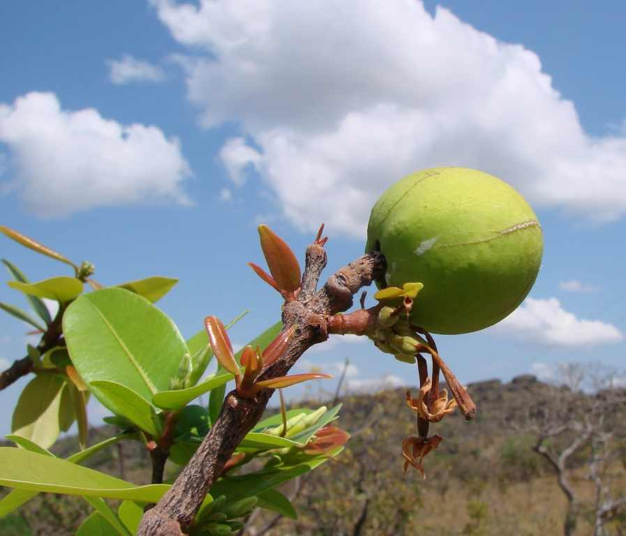

Fruto da mangaba - *Hancornia speciosa* (CC, Wikimedia)

### Contexto

As catadoras de mangaba de Sergipe são mulheres, majoritariamente negras, que praticam o extrativismo da mangaba (Hancornia speciosa) em áreas de restinga e tabuleiros costeiros.

- Reconhecidas como comunidade tradicional (Lei Estadual 7.082/2010)
- Ameaçadas pela especulação imobiliária e monocultura de cana e coco
- Organização em associações e movimentos sociais

### Extensão Rural e Mangaba

A experiência das catadoras demonstra:

- A importância de reconhecer **saberes femininos e negros** sobre o manejo de ecossistemas
- A necessidade de políticas que protejam áreas de **extrativismo coletivo**
- A potencialidade de **cadeias produtivas curtas** (polpas, geleias, beneficiamento)
- O papel da Embrapa Tabuleiros Costeiros na pesquisa participativa com catadoras

> O fruto da mangaba é, em Sergipe, **patrimônio cultural** e meio de vida para milhares de famílias.

## CASO - TERRA INDÍGENA XOCÓ (SE)

Os **Xocó** são o único povo indígena com terra demarcada em Sergipe, na Ilha de São Pedro, município de Porto da Folha, às margens do Rio São Francisco.

**Características:**

- População de aproximadamente **600 pessoas**
- Economia baseada em agricultura irrigada, pesca e artesanato
- Conflitos históricos com fazendeiros pela posse da ilha
- Demarcação conquistada em 1991 após décadas de luta

**Relevância para o agrônomo:** o caso Xocó ilustra que a questão indígena em Sergipe é real e próxima, não se restringe à Amazônia. O profissional formado pela UFS deve estar preparado para atuar com **sensibilidade intercultural** em seu próprio estado.

## O PAPEL DO ENGENHEIRO AGRÔNOMO

A formação do engenheiro agrônomo comprometido com a diversidade étnico-racial implica:

**Na prática profissional:**

- Reconhecer e respeitar os sistemas produtivos tradicionais antes de propor inovações
- Incorporar a **consulta prévia** como procedimento padrão em projetos que afetem comunidades tradicionais
- Emitir receituário agronômico com atenção à saúde de populações vulneráveis
- Articular-se com órgãos de proteção (FUNAI, Fundação Palmares, INCRA)

**Na postura ética:**

- Combater o racismo institucional nas entidades de ATER
- Promover a visibilidade de técnicos e pesquisadores negros e indígenas
- Contribuir para a inclusão produtiva de comunidades historicamente marginalizadas

## CONCLUSÃO

A diversidade étnico-racial do campo brasileiro é constitutiva da nossa agricultura, da nossa alimentação e da nossa paisagem. Invisibilizar essa contribuição é reproduzir a violência colonial que fundou a estrutura agrária desigual.

O engenheiro agrônomo formado pela UFS deve compreender que quilombolas, indígenas e comunidades tradicionais não são “público-alvo” da extensão rural, mas **sujeitos de direitos** e **co-autores de conhecimento** agrícola, cuja participação é condição para qualquer desenvolvimento rural que se pretenda sustentável, justo e democrático.

## REFERÊNCIAS

- Almeida, A. W. B. Terras tradicionalmente ocupadas (2008)
- Almeida, S. L. Racismo Estrutural (2019)
- Balée, W. The Research Program of Historical Ecology (2006)
- Brasil. Constituição Federal (1988) - Art. 68 ADCT, Art. 231
- Brasil. Lei 10.639/2003 - Ensino de História e Cultura Afro-Brasileira
- Brasil. Lei 11.645/2008 - Inclusão da Temática Indígena
- Brasil. Decreto 4.887/2003 - Regulamentação de Terras Quilombolas
- Brasil. Decreto 6.040/2007 - PNPCT
- Fundação Palmares. Certidões de autodefinição quilombola (2023)
- IBGE. Censo 2022 - Populações Indígenas (2023)
- ISA. Terras Indígenas no Brasil (2023)
- Posey, D. A. Indigenous management of tropical forest ecosystems (1985)

Obrigado!

Luiz Diego Vidal Santos

Universidade Federal de Sergipe (UFS)